# Larsson2019

Wancen Mu, Hirak Sarkar, Avi Srivastava, Kwangbom Choi, Rob Patro, Michael I. Love

Feb 1, 2021

Abstract

Airpart identifies sets of genes displaying differential cell-type-specific allelic imbalance across cell types or states, utilizing single-cell allelic counts. It makes use of a generalized fused lasso with binomial observations of allelic counts to partition cell types by their allelic imbalance. Alternatively, a nonparametric method for partitioning cell types is offered. The package includes a number of visualizations and quality control functions for examining single cell allelic imbalance datasets.

# Load data

First, we load the preprocessed [Larsson 2019](https://www.nature.com/articles/s41586-018-0836-1) data. It includes one maternal allelic counts(`c57`) and paternal allelic counts(`cast`) which was derived after removing some low quality cells indicated in the previous paper. `celltype` is a character vector of all cell types.

```r
suppressPackageStartupMessages(library(SingleCellExperiment))
load("../data/larsson.rda")
cell_meta_unique <- c("mESC","G1","S","G2M")
order_of_development <- order(match(celltype$x,cell_meta_unique))
assay.list<-list(a1=c57[,order_of_development],a2=cast[,order_of_development])
coldata<-data.frame(x=factor(celltype$x[order_of_development],levels=cell_meta_unique))
sce<-SingleCellExperiment(assays=assay.list, colData=coldata)
```

# Create Ratio matrix

Here we add the pseudo count for gene clustering and visualization.

```r
sce <- preprocess(sce)
```

Take a look at highest expressed genes

```r
counts(sce)[order(rowSums(counts(sce)),decreasing = T)[1:10],sample(dim(sce)[2],5)]
```

```
##        SS3_MAF_leo180223_p4_S131 SS3_MAF_leo180223_p4_S122 SS3_mESC_p1_B4_S26
## Malat1                       243                       614                166
## Acta2                        116                       256                  0
## Sparc                        109                       174                  0
## Lgals1                       173                       250                  0
## Rps3                          67                       102                127
## Col1a1                       109                       184                  0
## Thbs1                         63                       113                  0
## Rpl13a                        62                        97                 77
## Rps11                         62                       142                 82
## S100a6                       123                       200                  0
##        SS3_mESC_p1_E10_S77 SS3_mESC_p1_E6_S45
## Malat1                 304                183
## Acta2                    0                  0
## Sparc                   18                  6
## Lgals1                   0                  0
## Rps3                   126                154
## Col1a1                   0                  0
## Thbs1                    0                  0
## Rpl13a                 106                155
## Rps11                   74                113
## S100a6                   0                  0
```

# Quality control step

## QC on cells

```r
cellQCmetrics<-cellQC(sce,mad_detected=3,mad_spikegenes = 4,spike = "Ercc")
cellQCmetrics
```

```
## DataFrame with 412 rows and 7 columns
##                                  x       sum  detected spikePercent filter_sum
##                           <factor> <numeric> <numeric>    <numeric>  <logical>
## SS3_mESC_p1_A1_S1             mESC   4.31542      4186    0.0532353       TRUE
## SS3_mESC_p1_E1_S5             mESC   4.40846      4668    0.0977020       TRUE
## SS3_mESC_p1_C3_S19            mESC   4.44761      4796    0.0321199       TRUE
## SS3_mESC_p1_F2_S14            mESC   4.37374      4717    0.0507765       TRUE
## SS3_mESC_p1_A3_S17            mESC   4.08785      3356    0.0572129       TRUE
## ...                            ...       ...       ...          ...        ...
## SS3_MAF_leo180223_p4_S150      G2M   4.02206      2981    0.0760963       TRUE
## SS3_MAF_leo180223_p4_S151      G2M   4.56083      5521    0.0605144       TRUE
## SS3_MAF_leo180223_p4_S158      G2M   4.67636      6343    0.0632471       TRUE
## SS3_MAF_leo180223_p4_S187      G2M   4.16029      3756    0.0830335       TRUE
## SS3_MAF_leo180223_p4_S191      G2M   4.01812      2486    0.0479800       TRUE
##                           filter_detected filter_spike
##                                 <logical>    <logical>
## SS3_mESC_p1_A1_S1                    TRUE         TRUE
## SS3_mESC_p1_E1_S5                    TRUE         TRUE
## SS3_mESC_p1_C3_S19                   TRUE         TRUE
## SS3_mESC_p1_F2_S14                   TRUE         TRUE
## SS3_mESC_p1_A3_S17                   TRUE         TRUE
## ...                                   ...          ...
## SS3_MAF_leo180223_p4_S150            TRUE         TRUE
## SS3_MAF_leo180223_p4_S151            TRUE         TRUE
## SS3_MAF_leo180223_p4_S158            TRUE         TRUE
## SS3_MAF_leo180223_p4_S187            TRUE         TRUE
## SS3_MAF_leo180223_p4_S191           FALSE         TRUE
```

Now define cell filtering automatically or users can manually filter out based on `sum`,`detected` and `spikePercent`.

```r
keep_cell <- (
  cellQCmetrics$filter_sum & # sufficient features (genes)
  cellQCmetrics$filter_detected & # sufficient molecules counted
  cellQCmetrics$filter_spike  # sufficient features expressed compared to spike genes, high quality cells
)
table(keep_cell)
```

```
## keep_cell
## FALSE  TRUE
##    16   396
```

```r
sce<-sce[,keep_cell]
```

## QC on genes

Note that we require genes expressed in at least **25%** cells within each cell types.

```r
featureQCmetric<-featureQC(sce,spike = "Ercc",sd = 0.025)
keep_feature<-(featureQCmetric$filter_celltype &
                 featureQCmetric$filter_sd &
                 featureQCmetric$filter_spike)
table(keep_feature)
```

```
## keep_feature
## FALSE  TRUE
##  7441  2580
```

```r
sce<-sce[keep_feature,]
```

# Gene clustering

We provide two methods for gene clustering.

## * Gaussian Mixture modeling

Gaussian mixture modeling is the default method for gene clustering. The scatter plot is shown based on top 2 PCs of the smoothed allelic ratio data. The argument `plot=FALSE` can be used to avoid showing the plot. We have found gene clusters more spread out, more extreme allelic imbalance they have.

```r
sce<-geneCluster(sce, G=c(20,24,28))
```

```
## model-based optimal number of clusters: 28
```

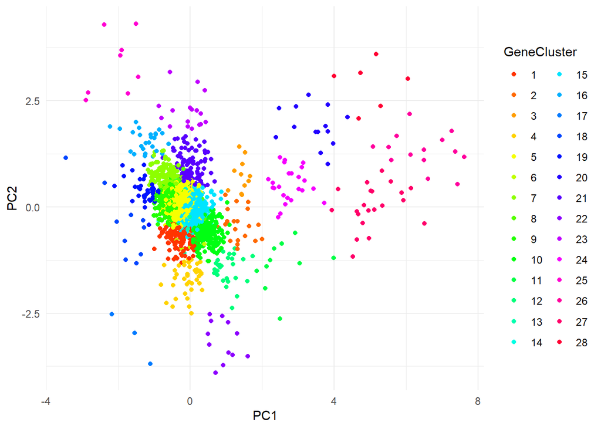

```r
metadata(sce)$geneCluster
```

```
## my_clusters
##   1   2   3   4   5   6   7   8   9  10  11  12  13  14  15  16  17  18  19  20
## 130  21  11  40 878   7 123   7 270 207  10  27  13   9 527  27   3  10  39  14
##  21  22  23  24  25  26  27  28
## 105  12  17  24   8  14  21   6
```

## Exclude chromosome X genes

Sex typeing allelic imbalance are excluded because we want to focus on genetically-driven AI. And `GMM` can actually successfully detected chr x and some imprinted genes in one gene cluster as below figure shows there are monoallelic pattern among fibroblast cells but in a coordinate way. So after removing all the genes on chromosome X, we redo the gene cluster step.

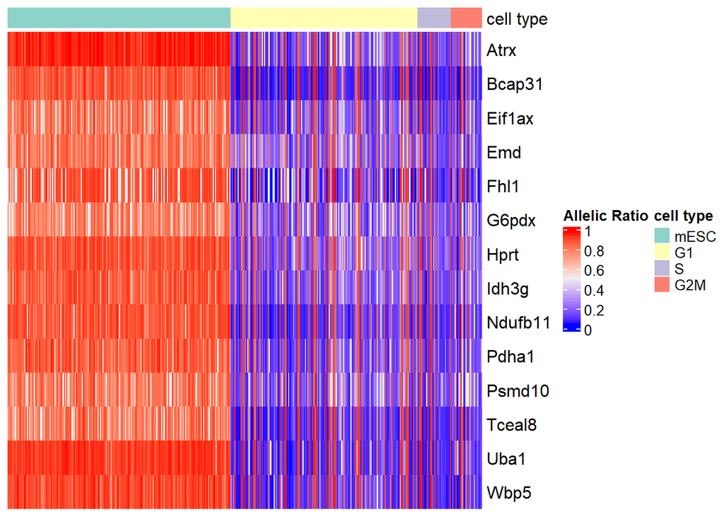

```r
makeHeatmap(sce,genecluster=26, show_row_names = TRUE)
```

```r
suppressMessages(suppressWarnings(library(GenomicFeatures)))
suppressMessages(suppressWarnings(library("org.Mm.eg.db")))
txdb <- makeTxDbFromGFF("ftp://ftp.ebi.ac.uk/pub/databases/gencode/Gencode_mouse/release_M1/gencode.vM1.annotation.gtf.gz")
g <- genes(txdb)
g$sym <- mapIds(org.Mm.eg.db, sub("\\..*","",names(g)), "SYMBOL", "ENSEMBL")
g <- g[!is.na(g$sym)]
```

```r
load("../data/mm9_genome.rda")
gene_chrx<- unname(g$sym[which(seqnames(g)=="chrX")])
sce <- sce[-which(rownames(sce)%in%gene_chrx),]
```

```r
sce<-geneCluster(sce, G=c(22,24,26))
```

```
## model-based optimal number of clusters: 24
```

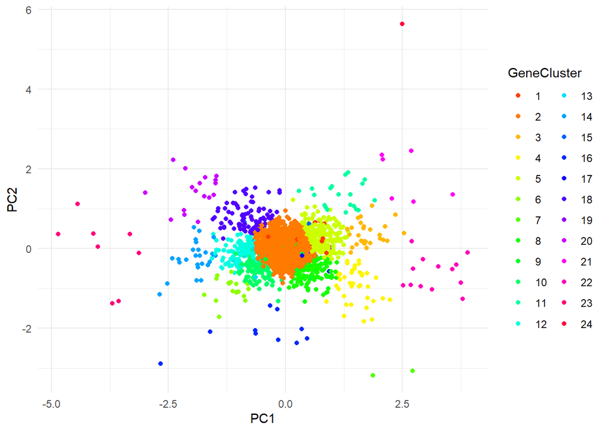

```r
metadata(sce)$geneCluster
```

```
## my_clusters
##    1    2    3    4    5    6    7    8    9   10   11   12   13   14   15   16
##   21 1567   28   40  232   18    2  108   16  126   20   99   13   26    9   10
##   17   18   19   20   21   22   23   24
##    8   90    3   17    6   13    8    1
```

## * Hierarchical clustering

Hierarchical clustering is an alternative way for clustering. Although in this dataset, it has similar number of clusters. We have found Gaussian mixture model approach (more similar genes within cluster, based on visual inspection in PC space and of allelic ratio heatmaps)

```r
sce.hc<-geneCluster(sce,method="hierarchical")
```

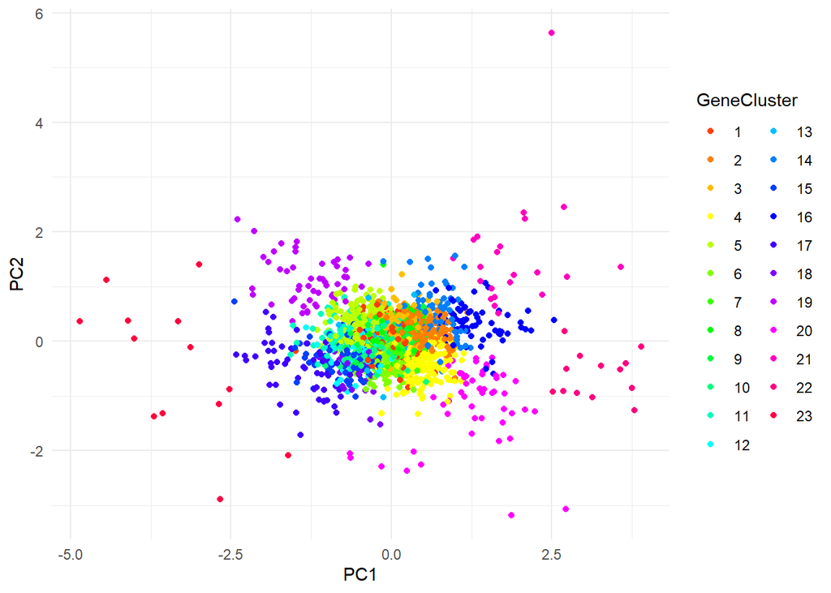

```r
metadata(sce.hc)$geneCluster
```

```
## my_clusters
##   1   2   3   4   5   6   7   8   9  10  11  12  13  14  15  16  17  18  19  20
## 219 211 211 196 173 169 155 127 117 107 105 103  91  90  70  70  63  55  51  50
##  21  22  23
##  22  13  13
```

## Generating null data and shows number of gene cluster is 1

To show that above gene clusters are not false positive, we simulated null allelic ratio 0.5 to all genes and it turns out only has one gene cluster.

```r
cts <- counts(sce)
a1 <- matrix(emdbook::rbetabinom(dim(cts)[1]*dim(cts)[2],
                             prob = 0.5,
                             size = cts,
                             theta = 20), ncol = dim(cts)[2])
a2 <- cts - a1
assay.list<-list(a1=a1,a2=a2)
sce.null<-SingleCellExperiment(assays=assay.list, colData=colData(sce))
sce.null <- preprocess(sce.null)
sce.null<-geneCluster(sce.null, G=c(1:4))
```

```
## model-based optimal number of clusters: 1
```

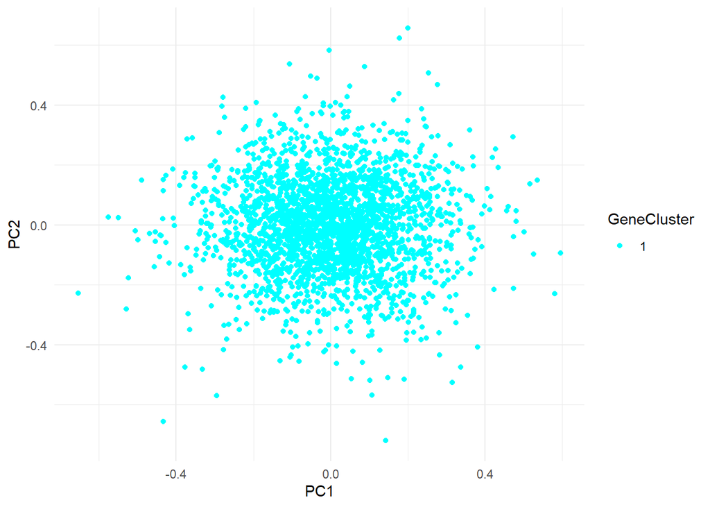

```r
metadata(sce.null)$geneCluster
```

```
## my_clusters
##    1
## 2481
```

# Running airpart

## Simple summary table of alleic ratio

Quickly look at the weighted mean of allelic ratio for each gene cluster. Identify the interested gene cluster. The following step is a complement of the QC on genes step. We recommend users only run *airpart* when the largest ordered allelic ratio difference > 0.05 for speed concerns. We find that the allelic ratio of most of the gene clusters in such cases (small absolute allelic ratio differences) won’t provide enough evidence to detect differential allelic imbalance.

```r
sce<-summaryAllelicRatio(sce)
summary<-metadata(sce)$summary
sapply(1:length(summary), function(i) {
  inst <- summary[[i]]
  inst_order <- inst[order(inst$weighted.mean), ]
  max(diff(inst_order$weighted.mean)) > 0.05
})
```

```
##  [1]  TRUE FALSE  TRUE  TRUE  TRUE  TRUE  TRUE  TRUE  TRUE  TRUE  TRUE FALSE
## [13]  TRUE  TRUE  TRUE  TRUE FALSE  TRUE  TRUE  TRUE  TRUE FALSE  TRUE  TRUE
```

Here we use gene cluster 3 and 9 as an example.

## Experiment-wide beta-binomial over-dispersion

We recommend examining the experiment-wide beta-binomial over-dispersion, which helps to inform whether to use a binomial likelihood or a nonparametric approach to partitioning the cell types by allelic imbalance.

For gene cluster 3, we found that it has smaller over-dispersion and gene cluster 9 has larger over-dispersion, so we would use fussed lasso method and pairwise Mann Whitney Wilcoxon extension methods to infer partition seperately.

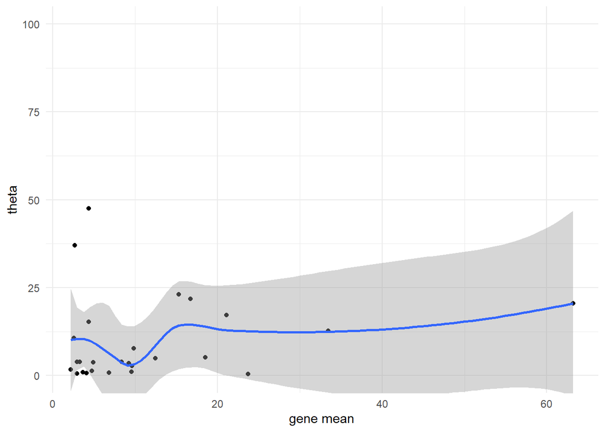

```r
estDisp(sce,genecluster = 3)
```

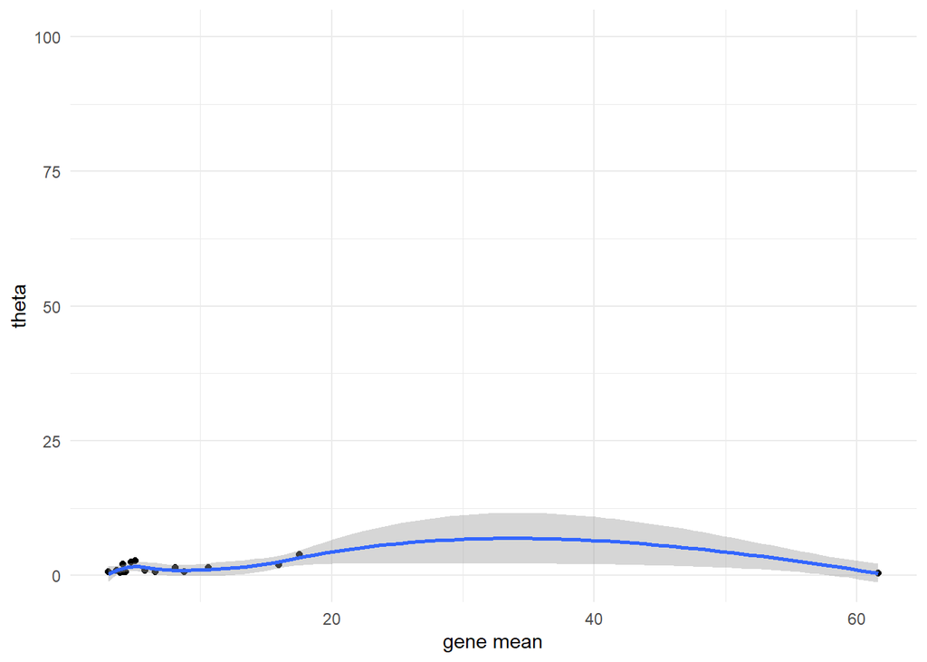

```r
estDisp(sce,genecluster = 9)
```

## Modeling using fused lasso with binomial likelihood

*airpart* offers a method for partitioning cell types using the generalized fused lasso with binomial likelihood, as implemented in the *smurf* package. Cell types are merged based on their similarity of allelic ratios, accounting for excess variability on the ratio from low counts. The penalization is determined using deviance on held-out data, with a 1 SE cross-validation rule for favoring smaller models (more fused cell types).

```r
sce_sub <- fusedLasso(sce,
  model = "binomial",
  genecluster = 3, ncores = 4
)
```

```r
knitr::kable(metadata(sce_sub)$partition, row.names = FALSE)
```

| part | x | coef |
| --- | --- | --- |
| 1 | mESC | 0.7447520 |
| 2 | G1 | 0.3791784 |
| 2 | S | 0.3791784 |
| 2 | G2M | 0.3791784 |

Here `ncores` is the number of CPU used for parallelization. Note, the computation time increases approximate linearly as number of genes increases. If you run `niter>1`, please use a `consensusPart` to derive the final partition.

Plotting a heatmap to show the cell types partition:

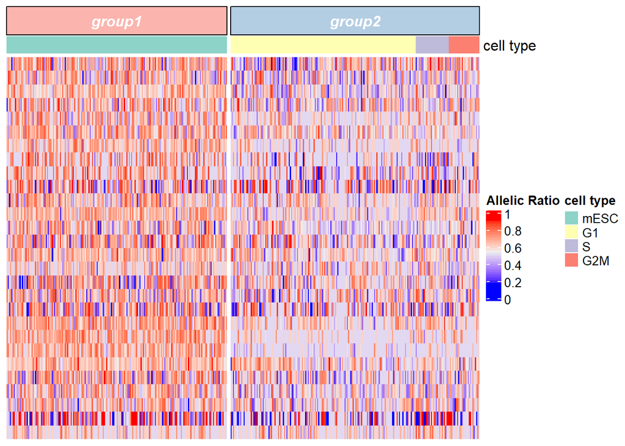

```r
makeHeatmap(sce_sub,order_by_group = FALSE)
```

## Modeling using pairwise Mann Whitney Wilcoxon extension

An alternative to the fused lasso with binomial likelihood is an extension we have implemented wherein all pairs cell types are compared with Mann Whitney Wilcoxon rank sum tests. In practice, we find that when the allelic counts deviates strongly from a binomial (e.g. large over-dispersion), the `wilcoxExt` function can offer improved performance, in terms of recovery of the true partition of cell types by allelic imbalance. The partition is decided based on a loss function motivated by the Bayesian Information Criteria

```r
thrs <- 10^seq(from = -1.6, to = -0.8, by = 0.1)
sce_sub <- wilcoxExt(sce, genecluster = 9, threshold = thrs)
knitr::kable(metadata(sce_sub)$partition, row.names = FALSE)
```

| part | x |
| --- | --- |
| 1 | mESC |
| 2 | G1 |
| 1 | S |
| 1 | G2M |

```r
metadata(sce_sub)$threshold
```

[1] 0.06309573

## Calculating allelic ratio estimate via beta-binomial

After *airpart* determines a partition of cell types either by the fused lasso with binomial likelihood or the nonparametric approach described above, it give fused lasso estimate or weighted mean as prior Cauchy mean to estimate the allelic ratio per gene and per cell type (and credible intervals) via beta-binomial loglikelihood, using functionality from the *apeglm* package.

Note that the estimates and confidence intervals are not equal for cell types in the same partition and for genes, because in this step we re-estimate the conditional cell type means per original cell type and accounting for each gene overdispersion. The dispersion parameter is using Efron-like formula shrinkage.

A violin plot with posterior mean allelic ratios on the y-axis: We can see that G2M and S has less cells in cell types, so both violin plot and forestplot shows a longer ranges or credible interval in these two cell types.

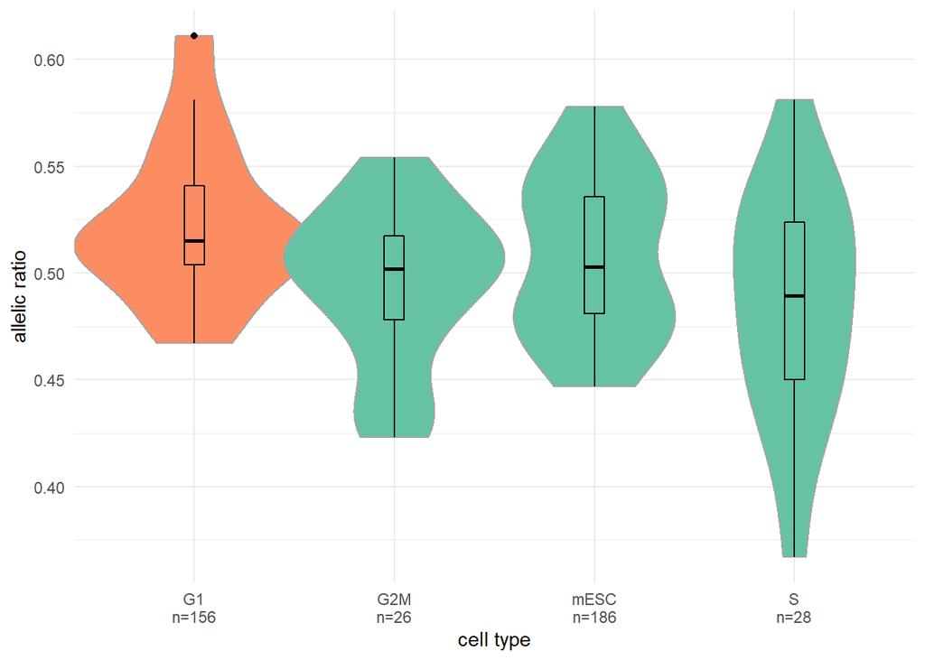

```r
sce_sub <- allelicRatio(sce_sub)
makeViolin(sce_sub)
```

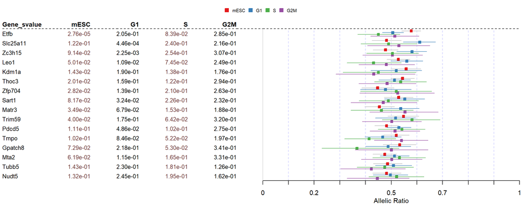

```r
sce_sub <- allelicRatio(sce_sub)
makeForest(sce_sub,showtext = TRUE)
```

Finally, a heatmap as before, but now with the cell types grouped according to the partition:

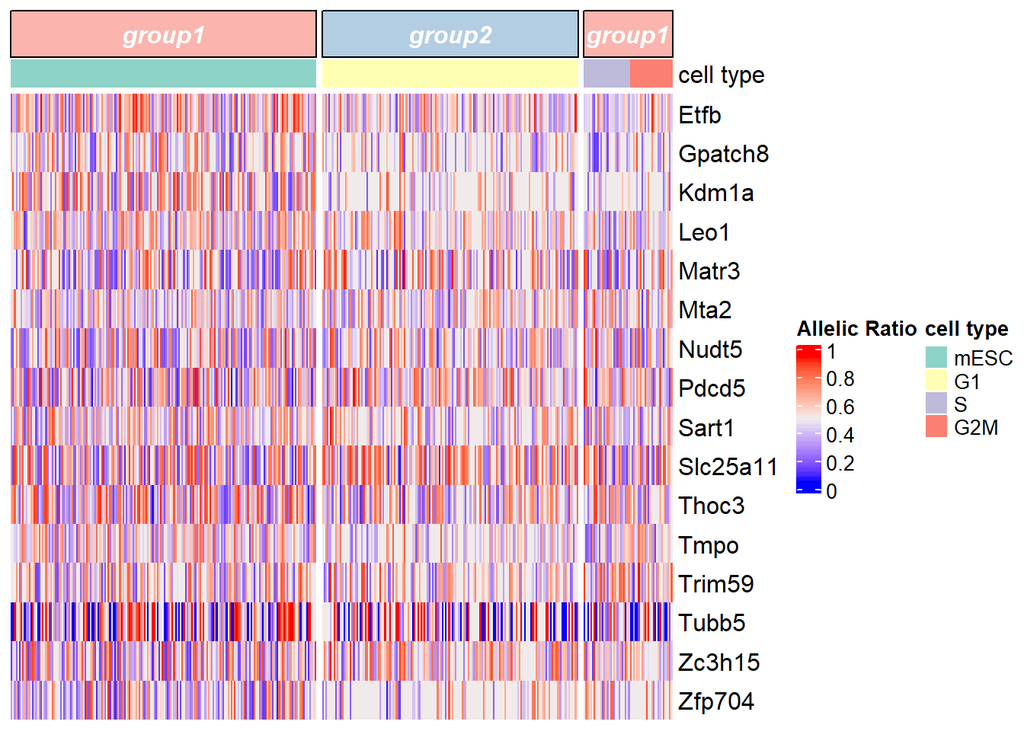

```r
makeHeatmap(sce_sub, order_by_group = FALSE, show_row_names = TRUE)
```

## GO term analysis

Through GO term evaluation, we can find indeed `regulation of myeloid cell differentiation` and differential `gene expression` GO terms has significant p value.

```r
library(goseq)
i=9
feat<-which(rowData(sce)$cluster==i)
genes <- rep(0,nrow(sce))
names(genes) <- rownames(sce)
genes[feat] <- 1
table(genes)
```

genes 0 1 2465 16

```r
suppressMessages(pwf <- nullp(genes, "mm9", "geneSymbol"))
```

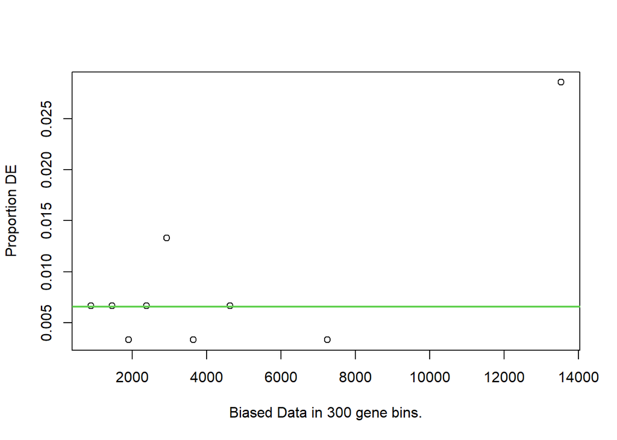

```r
suppressMessages(gores <- goseq(pwf, "mm9", "geneSymbol"))
knitr::kable(head(gores[gores$ontology=="BP" & gores$numInCat>10,], 15))
```

|  | category | over_represented_pvalue | under_represented_pvalue | numDEInCat | numInCat | term | ontology |
| --- | --- | --- | --- | --- | --- | --- | --- |
| 3688 | GO:0016574 | 0.0027076 | 0.9999466 | 2 | 12 | histone ubiquitination | BP |
| 12023 | GO:1903706 | 0.0056149 | 0.9995890 | 3 | 56 | regulation of hemopoiesis | BP |
| 12025 | GO:1903708 | 0.0116994 | 0.9994701 | 2 | 25 | positive regulation of hemopoiesis | BP |
| 1769 | GO:0006325 | 0.0118303 | 0.9983383 | 4 | 139 | chromatin organization | BP |
| 704 | GO:0002682 | 0.0136953 | 0.9979889 | 4 | 145 | regulation of immune system process | BP |
| 8682 | GO:0051701 | 0.0155886 | 0.9991718 | 2 | 29 | interaction with host | BP |
| 706 | GO:0002684 | 0.0177574 | 0.9979868 | 3 | 85 | positive regulation of immune system process | BP |
| 7413 | GO:0045637 | 0.0188131 | 0.9988904 | 2 | 32 | regulation of myeloid cell differentiation | BP |
| 1775 | GO:0006338 | 0.0235159 | 0.9984297 | 2 | 36 | chromatin remodeling | BP |
| 3684 | GO:0016570 | 0.0238581 | 0.9969656 | 3 | 95 | histone modification | BP |
| 3683 | GO:0016569 | 0.0252028 | 0.9967249 | 3 | 97 | covalent chromatin modification | BP |
| 656 | GO:0002376 | 0.0383648 | 0.9908157 | 5 | 293 | immune system process | BP |
| 2936 | GO:0010467 | 0.0392900 | 0.9881959 | 10 | 897 | gene expression | BP |
| 4420 | GO:0030097 | 0.0513336 | 0.9911281 | 3 | 128 | hemopoiesis | BP |
| 8522 | GO:0051276 | 0.0545766 | 0.9875450 | 4 | 221 | chromosome organization | BP |